# Interactive effects of task repetition, task motivation and task engagement on CAL in L2 writing

Webpage created and maintained by Reza Norouzian* © 2022-present

Reza Norouzian

1/3/2023

# 1 RQ1: To what extent does task repetition associate with measures of L2 writing syntactic complexity, accuracy, and lexical complexity?

The association between task repetition and CAL measures

| time | cal | Mean | SE | Lower | Upper | t | p-value | Sig. |
| --- | --- | --- | --- | --- | --- | --- | --- | --- |
| 1 | ac_EFC/C | 0.30 | 0.08 | 0.13 | 0.46 | 3.59 | 0.00 | *** |
| 2 | ac_EFC/C | 0.46 | 0.06 | 0.35 | 0.58 | 7.94 | 0.00 | *** |
| 3 | ac_EFC/C | 0.37 | 0.05 | 0.26 | 0.48 | 6.75 | 0.00 | *** |
| 4 | ac_EFC/C | 0.95 | 0.05 | 0.85 | 1.05 | 19.12 | 0.00 | *** |
| 1 | com_CN/C | 1.06 | 0.03 | 1.00 | 1.12 | 33.95 | 0.00 | *** |
| 2 | com_CN/C | 1.09 | 0.02 | 1.05 | 1.14 | 51.55 | 0.00 | *** |
| 3 | com_CN/C | 1.08 | 0.02 | 1.04 | 1.12 | 54.66 | 0.00 | *** |
| 4 | com_CN/C | 1.11 | 0.02 | 1.07 | 1.14 | 62.66 | 0.00 | *** |
| 1 | com_CN/T | 1.83 | 0.02 | 1.80 | 1.86 | 117.30 | 0.00 | *** |
| 2 | com_CN/T | 1.82 | 0.01 | 1.80 | 1.84 | 171.33 | 0.00 | *** |
| 3 | com_CN/T | 1.89 | 0.01 | 1.87 | 1.91 | 190.85 | 0.00 | *** |
| 4 | com_CN/T | 1.91 | 0.01 | 1.89 | 1.92 | 215.63 | 0.00 | *** |
| 1 | com_DC/T | 0.78 | 0.09 | 0.60 | 0.96 | 8.77 | 0.00 | *** |
| 2 | com_DC/T | 0.80 | 0.06 | 0.68 | 0.92 | 13.31 | 0.00 | *** |
| 3 | com_DC/T | 1.05 | 0.06 | 0.94 | 1.16 | 18.62 | 0.00 | *** |
| 4 | com_DC/T | 0.95 | 0.05 | 0.85 | 1.05 | 18.91 | 0.00 | *** |
| 1 | com_MLTU | 15.72 | 0.19 | 15.34 | 16.10 | 82.72 | 0.00 | *** |
| 2 | com_MLTU | 15.92 | 0.13 | 15.66 | 16.18 | 123.30 | 0.00 | *** |
| 3 | com_MLTU | 16.51 | 0.12 | 16.27 | 16.75 | 137.07 | 0.00 | *** |
| 4 | com_MLTU | 17.07 | 0.11 | 16.85 | 17.28 | 158.77 | 0.00 | *** |
| 1 | lex_Vocd | 69.26 | 1.07 | 67.12 | 71.39 | 64.49 | 0.00 | *** |
| 2 | lex_Vocd | 69.09 | 0.73 | 67.64 | 70.54 | 94.36 | 0.00 | *** |
| 3 | lex_Vocd | 70.82 | 0.68 | 69.46 | 72.17 | 103.59 | 0.00 | *** |
| 4 | lex_Vocd | 72.16 | 0.61 | 70.95 | 73.37 | 118.04 | 0.00 | *** |
| 1 | lex_WRDFRQmc | 1.72 | 0.02 | 1.69 | 1.75 | 114.15 | 0.00 | *** |
| 2 | lex_WRDFRQmc | 1.73 | 0.01 | 1.70 | 1.75 | 167.46 | 0.00 | *** |
| 3 | lex_WRDFRQmc | 1.74 | 0.01 | 1.72 | 1.76 | 181.27 | 0.00 | *** |
| 4 | lex_WRDFRQmc | 1.76 | 0.01 | 1.75 | 1.78 | 205.04 | 0.00 | *** |

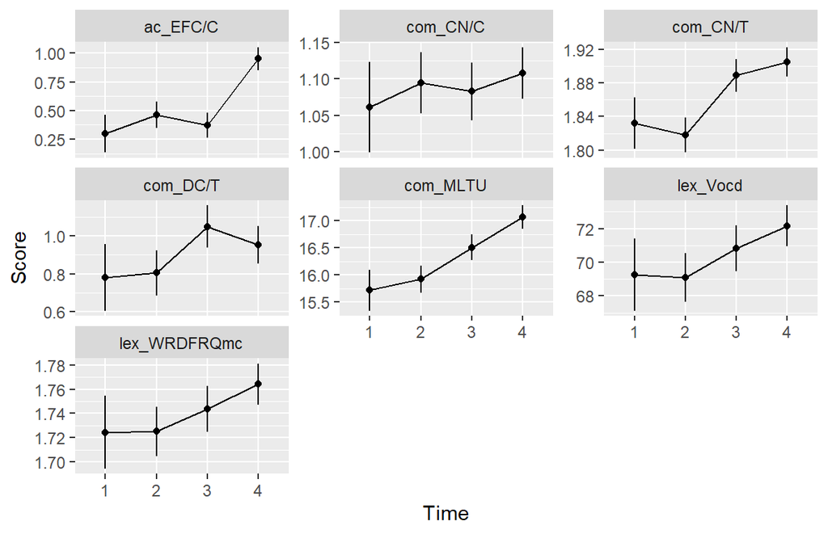

# 2 RQ2a: To what extent is that association moderated by the level of task difficulty?

The association between task repetition and CAL measures moderated by task difficulty

task_dif

time

cal

Mean

SE

Lower

Upper

t

p-value

Sig.

complex

1

ac_EFC/C

0.334

0.113

0.109

0.558

2.949

0.004

simple

1

ac_EFC/C

0.260

0.113

0.036

0.485

2.299

0.024

complex

2

ac_EFC/C

0.365

0.080

0.208

0.523

4.594

0.000

***

simple

2

ac_EFC/C

0.559

0.080

0.402

0.717

7.033

0.000

***

complex

3

ac_EFC/C

0.429

0.074

0.282

0.576

5.803

0.000

***

simple

3

ac_EFC/C

0.311

0.074

0.164

0.457

4.204

0.000

***

complex

4

ac_EFC/C

0.682

0.067

0.550

0.815

10.212

0.000

***

simple

4

ac_EFC/C

1.222

0.067

1.089

1.354

18.293

0.000

***

complex

1

com_CN/C

1.025

0.044

0.938

1.111

23.501

0.000

***

simple

1

com_CN/C

1.098

0.044

1.011

1.184

25.171

0.000

***

complex

2

com_CN/C

1.104

0.030

1.045

1.164

36.836

0.000

***

simple

2

com_CN/C

1.085

0.030

1.026

1.145

36.212

0.000

***

complex

3

com_CN/C

1.021

0.028

0.966

1.076

36.894

0.000

***

simple

3

com_CN/C

1.145

0.028

1.090

1.200

41.385

0.000

***

complex

4

com_CN/C

1.109

0.025

1.060

1.158

44.884

0.000

***

simple

4

com_CN/C

1.107

0.025

1.058

1.156

44.829

0.000

***

complex

1

com_CN/T

1.789

0.022

1.746

1.832

81.929

0.000

***

simple

1

com_CN/T

1.875

0.022

1.832

1.918

85.863

0.000

***

complex

2

com_CN/T

1.825

0.015

1.795

1.855

121.588

0.000

***

simple

2

com_CN/T

1.811

0.015

1.781

1.841

120.682

0.000

***

complex

3

com_CN/T

1.901

0.014

1.874

1.928

137.242

0.000

***

simple

3

com_CN/T

1.877

0.014

1.850

1.905

135.523

0.000

***

complex

4

com_CN/T

1.894

0.012

1.869

1.919

153.144

0.000

***

simple

4

com_CN/T

1.916

0.012

1.892

1.941

154.940

0.000

***

complex

1

com_DC/T

0.701

0.125

0.452

0.950

5.586

0.000

***

simple

1

com_DC/T

0.861

0.125

0.612

1.110

6.863

0.000

***

complex

2

com_DC/T

0.733

0.086

0.562

0.904

8.506

0.000

***

simple

2

com_DC/T

0.876

0.086

0.705

1.048

10.166

0.000

***

complex

3

com_DC/T

1.047

0.080

0.889

1.205

13.156

0.000

***

simple

3

com_DC/T

1.054

0.080

0.897

1.212

13.251

0.000

***

complex

4

com_DC/T

0.878

0.071

0.737

1.019

12.356

0.000

***

simple

4

com_DC/T

1.027

0.071

0.886

1.168

14.457

0.000

***

complex

1

com_MLTU

15.200

0.264

14.676

15.724

57.530

0.000

***

simple

1

com_MLTU

16.237

0.264

15.713

16.761

61.455

0.000

***

complex

2

com_MLTU

15.587

0.182

15.226

15.947

85.833

0.000

***

simple

2

com_MLTU

16.252

0.182

15.892

16.613

89.499

0.000

***

complex

3

com_MLTU

16.556

0.168

16.223

16.888

98.782

0.000

***

simple

3

com_MLTU

16.460

0.168

16.127

16.793

98.211

0.000

***

complex

4

com_MLTU

17.028

0.150

16.731

17.325

113.790

0.000

***

simple

4

com_MLTU

17.107

0.150

16.810

17.404

114.317

0.000

***

complex

1

lex_Vocd

70.390

1.509

67.396

73.384

46.649

0.000

***

simple

1

lex_Vocd

68.122

1.509

65.128

71.116

45.146

0.000

***

complex

2

lex_Vocd

69.316

1.037

67.258

71.374

66.836

0.000

***

simple

2

lex_Vocd

68.860

1.037

66.802

70.918

66.397

0.000

***

complex

3

lex_Vocd

72.334

0.957

70.435

74.234

75.570

0.000

***

simple

3

lex_Vocd

69.299

0.957

67.399

71.198

72.399

0.000

***

complex

4

lex_Vocd

71.050

0.855

69.354

72.746

83.136

0.000

***

simple

4

lex_Vocd

73.270

0.855

71.575

74.966

85.734

0.000

***

complex

1

lex_WRDFRQmc

1.717

0.021

1.675

1.759

80.871

0.000

***

simple

1

lex_WRDFRQmc

1.732

0.021

1.690

1.774

81.587

0.000

***

complex

2

lex_WRDFRQmc

1.710

0.015

1.681

1.739

116.713

0.000

***

simple

2

lex_WRDFRQmc

1.740

0.015

1.711

1.769

118.787

0.000

***

complex

3

lex_WRDFRQmc

1.759

0.014

1.732

1.786

129.889

0.000

***

simple

3

lex_WRDFRQmc

1.729

0.014

1.702

1.756

127.674

0.000

***

complex

4

lex_WRDFRQmc

1.773

0.012

1.749

1.797

146.310

0.000

***

simple

4

lex_WRDFRQmc

1.755

0.012

1.731

1.779

144.841

0.000

***

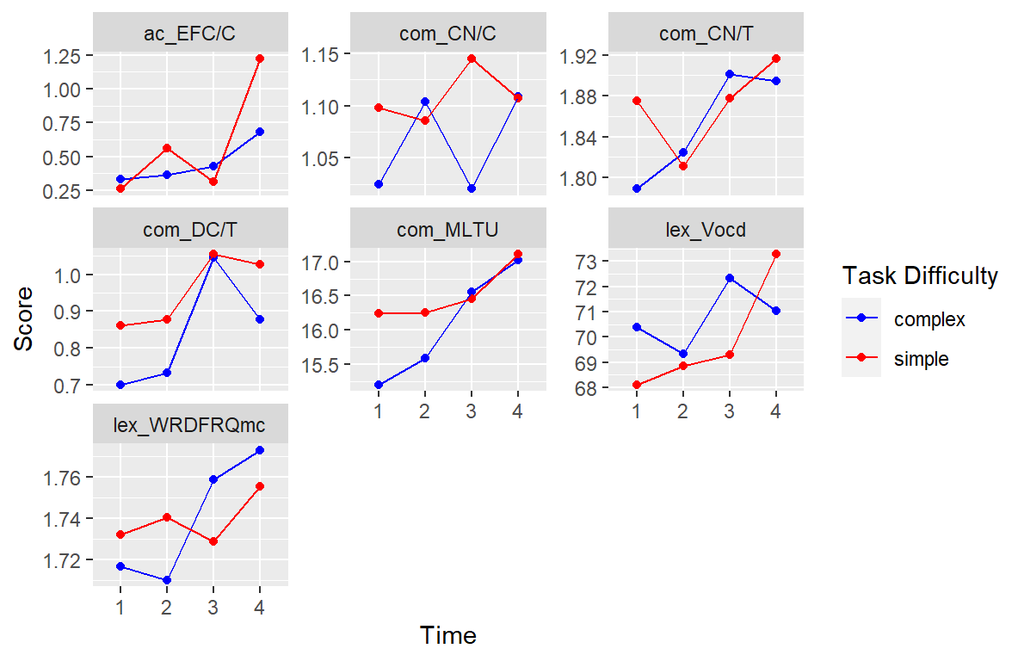

# 3 RQ2b:

## 3.1 To what extent is that association moderated by the level of task external motivation?

The association between task repetition and CAL measures moderated by external motivation

| extr | time | cal | Mean | SE | Lower | Upper | t | p-value | Sig. |
| --- | --- | --- | --- | --- | --- | --- | --- | --- | --- |
| 2.100 | 1 | ac_EFC/C | 0.333 | 0.094 | 0.146 | 0.521 | 3.536 | 0.001 | *** |
| 3.200 | 1 | ac_EFC/C | 0.274 | 0.086 | 0.103 | 0.444 | 3.185 | 0.002 | ** |
| 4.300 | 1 | ac_EFC/C | 0.214 | 0.139 | -0.061 | 0.490 | 1.543 | 0.126 |  |
| 2.100 | 2 | ac_EFC/C | 0.399 | 0.072 | 0.256 | 0.541 | 5.551 | 0.000 | *** |
| 3.200 | 2 | ac_EFC/C | 0.480 | 0.058 | 0.366 | 0.595 | 8.305 | 0.000 | *** |
| 4.300 | 2 | ac_EFC/C | 0.562 | 0.090 | 0.385 | 0.740 | 6.276 | 0.000 | *** |
| 2.100 | 3 | ac_EFC/C | 0.440 | 0.086 | 0.269 | 0.610 | 5.121 | 0.000 | *** |
| 3.200 | 3 | ac_EFC/C | 0.383 | 0.054 | 0.276 | 0.490 | 7.091 | 0.000 | *** |
| 4.300 | 3 | ac_EFC/C | 0.326 | 0.068 | 0.191 | 0.460 | 4.811 | 0.000 | *** |
| 2.100 | 4 | ac_EFC/C | 0.616 | 0.077 | 0.463 | 0.768 | 8.026 | 0.000 | *** |
| 3.200 | 4 | ac_EFC/C | 0.885 | 0.049 | 0.788 | 0.982 | 18.115 | 0.000 | *** |
| 4.300 | 4 | ac_EFC/C | 1.154 | 0.060 | 1.036 | 1.273 | 19.346 | 0.000 | *** |
| 2.100 | 1 | com_CN/C | 1.046 | 0.036 | 0.973 | 1.118 | 28.766 | 0.000 | *** |
| 3.200 | 1 | com_CN/C | 1.071 | 0.033 | 1.006 | 1.137 | 32.338 | 0.000 | *** |
| 4.300 | 1 | com_CN/C | 1.097 | 0.054 | 0.991 | 1.203 | 20.481 | 0.000 | *** |
| 2.100 | 2 | com_CN/C | 1.114 | 0.027 | 1.060 | 1.168 | 41.199 | 0.000 | *** |
| 3.200 | 2 | com_CN/C | 1.089 | 0.022 | 1.046 | 1.132 | 50.077 | 0.000 | *** |
| 4.300 | 2 | com_CN/C | 1.064 | 0.034 | 0.997 | 1.131 | 31.516 | 0.000 | *** |
| 2.100 | 3 | com_CN/C | 1.002 | 0.032 | 0.938 | 1.066 | 31.186 | 0.000 | *** |
| 3.200 | 3 | com_CN/C | 1.068 | 0.020 | 1.028 | 1.108 | 53.011 | 0.000 | *** |
| 4.300 | 3 | com_CN/C | 1.134 | 0.025 | 1.083 | 1.184 | 44.779 | 0.000 | *** |
| 2.100 | 4 | com_CN/C | 1.107 | 0.028 | 1.051 | 1.163 | 39.081 | 0.000 | *** |
| 3.200 | 4 | com_CN/C | 1.108 | 0.018 | 1.072 | 1.143 | 61.586 | 0.000 | *** |
| 4.300 | 4 | com_CN/C | 1.109 | 0.022 | 1.065 | 1.152 | 50.376 | 0.000 | *** |
| 2.100 | 1 | com_CN/T | 1.800 | 0.018 | 1.764 | 1.836 | 99.175 | 0.000 | *** |
| 3.200 | 1 | com_CN/T | 1.852 | 0.017 | 1.820 | 1.885 | 111.992 | 0.000 | *** |
| 4.300 | 1 | com_CN/T | 1.905 | 0.027 | 1.852 | 1.958 | 71.235 | 0.000 | *** |
| 2.100 | 2 | com_CN/T | 1.823 | 0.014 | 1.796 | 1.849 | 134.996 | 0.000 | *** |
| 3.200 | 2 | com_CN/T | 1.817 | 0.011 | 1.795 | 1.838 | 167.278 | 0.000 | *** |
| 4.300 | 2 | com_CN/T | 1.811 | 0.017 | 1.777 | 1.844 | 107.376 | 0.000 | *** |

[output cut: 54 more lines]

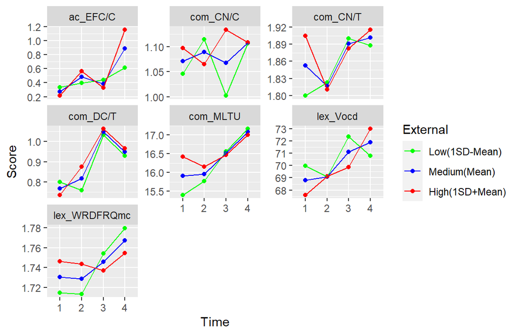

## 3.2 To what extent is that association moderated by the level of task intrinsic motivation?

The association between task repetition and CAL measures moderated by intrinsic motivation

intr

time

cal

Mean

SE

Lower

Upper

t

p-value

Sig.

1.800

1

ac_EFC/C

0.272

0.130

0.015

0.529

2.103

0.038

3.000

1

ac_EFC/C

0.293

0.082

0.131

0.455

3.586

0.001

***

4.100

1

ac_EFC/C

0.311

0.099

0.114

0.508

3.138

0.002

1.800

2

ac_EFC/C

0.618

0.102

0.415

0.821

6.041

0.000

***

3.000

2

ac_EFC/C

0.502

0.060

0.383

0.622

8.330

0.000

***

4.100

2

ac_EFC/C

0.396

0.067

0.263

0.529

5.916

0.000

***

1.800

3

ac_EFC/C

0.338

0.063

0.213

0.463

5.372

0.000

***

3.000

3

ac_EFC/C

0.390

0.057

0.277

0.502

6.883

0.000

***

4.100

3

ac_EFC/C

0.437

0.090

0.258

0.617

4.832

0.000

***

1.800

4

ac_EFC/C

1.132

0.057

1.019

1.245

19.868

0.000

***

3.000

4

ac_EFC/C

0.861

0.050

0.762

0.960

17.240

0.000

***

4.100

4

ac_EFC/C

0.612

0.076

0.460

0.763

7.996

0.000

***

1.800

1

com_CN/C

1.155

0.050

1.055

1.254

23.118

0.000

***

3.000

1

com_CN/C

1.078

0.031

1.015

1.140

34.288

0.000

***

4.100

1

com_CN/C

1.007

0.038

0.931

1.083

26.356

0.000

***

1.800

2

com_CN/C

1.087

0.039

1.010

1.164

28.111

0.000

***

3.000

2

com_CN/C

1.093

0.023

1.048

1.138

48.055

0.000

***

4.100

2

com_CN/C

1.098

0.025

1.048

1.148

43.464

0.000

***

1.800

3

com_CN/C

1.120

0.024

1.073

1.167

47.479

0.000

***

3.000

3

com_CN/C

1.060

0.021

1.018

1.102

49.961

0.000

***

4.100

3

com_CN/C

1.005

0.034

0.937

1.072

29.597

0.000

***

1.800

4

com_CN/C

1.106

0.021

1.064

1.148

52.378

0.000

***

3.000

4

com_CN/C

1.109

0.018

1.072

1.145

59.966

0.000

***

4.100

4

com_CN/C

1.111

0.028

1.055

1.167

39.140

0.000

***

1.800

1

com_CN/T

1.896

0.025

1.846

1.946

75.679

0.000

***

3.000

1

com_CN/T

1.843

0.016

1.812

1.874

116.907

0.000

***

4.100

1

com_CN/T

1.795

0.019

1.757

1.833

93.628

0.000

***

1.800

2

com_CN/T

1.803

0.019

1.764

1.841

92.937

0.000

***

3.000

2

com_CN/T

1.814

0.011

1.792

1.837

159.037

0.000

***

4.100

2

com_CN/T

1.824

0.013

1.799

1.850

143.978

0.000

***

1.800

3

com_CN/T

1.882

0.012

1.858

1.905

159.073

0.000

***

3.000

3

com_CN/T

1.894

0.011

1.873

1.915

177.980

0.000

***

4.100

3

com_CN/T

1.905

0.017

1.871

1.938

111.843

0.000

***

1.800

4

com_CN/T

1.910

0.011

1.889

1.931

180.273

0.000

***

3.000

4

com_CN/T

1.903

0.009

1.884

1.921

205.145

0.000

***

4.100

4

com_CN/T

1.896

0.014

1.867

1.924

133.156

0.000

***

1.800

1

com_DC/T

1.012

0.144

0.727

1.297

7.053

0.000

***

3.000

1

com_DC/T

0.822

0.090

0.642

1.001

9.095

0.000

***

4.100

1

com_DC/T

0.647

0.110

0.429

0.865

5.889

0.000

***

1.800

2

com_DC/T

0.777

0.111

0.557

0.998

6.991

0.000

***

3.000

2

com_DC/T

0.798

0.065

0.668

0.927

12.207

0.000

***

4.100

2

com_DC/T

0.817

0.073

0.673

0.961

11.251

0.000

***

1.800

3

com_DC/T

1.071

0.068

0.937

1.206

15.805

0.000

***

3.000

3

com_DC/T

1.038

0.061

0.917

1.159

17.024

0.000

***

4.100

3

com_DC/T

1.007

0.098

0.814

1.201

10.323

0.000

***

1.800

4

com_DC/T

0.999

0.061

0.878

1.119

16.452

0.000

***

3.000

4

com_DC/T

0.929

0.053

0.824

1.035

17.485

0.000

***

4.100

4

com_DC/T

0.865

0.082

0.703

1.027

10.608

0.000

***

1.800

1

com_MLTU

16.242

0.304

15.639

16.845

53.426

0.000

***

3.000

1

com_MLTU

15.811

0.191

15.431

16.190

82.635

0.000

***

4.100

1

com_MLTU

15.415

0.233

14.954

15.877

66.260

0.000

***

1.800

2

com_MLTU

16.429

0.235

15.962

16.896

69.784

0.000

***

3.000

2

com_MLTU

16.050

0.138

15.775

16.325

115.944

0.000

***

4.100

2

com_MLTU

15.703

0.154

15.398

16.008

102.117

0.000

***

1.800

3

com_MLTU

16.508

0.144

16.223

16.793

114.995

0.000

***

3.000

3

com_MLTU

16.508

0.129

16.252

16.764

127.850

0.000

***

4.100

3

com_MLTU

16.507

0.207

16.097

16.917

79.879

0.000

***

1.800

4

com_MLTU

17.107

0.129

16.851

17.362

133.040

0.000

***

3.000

4

com_MLTU

17.047

0.113

16.824

17.271

151.468

0.000

***

4.100

4

com_MLTU

16.993

0.173

16.650

17.336

98.359

0.000

***

1.800

1

lex_Vocd

67.664

1.729

64.234

71.094

39.138

0.000

***

3.000

1

lex_Vocd

68.975

1.088

66.816

71.134

63.390

0.000

***

4.100

1

lex_Vocd

70.177

1.323

67.552

72.803

53.041

0.000

***

1.800

2

lex_Vocd

68.360

1.339

65.703

71.016

51.058

0.000

***

3.000

2

lex_Vocd

68.901

0.787

67.339

70.464

87.522

0.000

***

4.100

2

lex_Vocd

69.398

0.875

67.663

71.133

79.357

0.000

***

1.800

3

lex_Vocd

69.667

0.816

68.047

71.287

85.333

0.000

***

3.000

3

lex_Vocd

71.531

0.734

70.074

72.988

97.415

0.000

***

4.100

3

lex_Vocd

73.241

1.175

70.909

75.573

62.319

0.000

***

1.800

4

lex_Vocd

72.606

0.731

71.155

74.057

99.290

0.000

***

3.000

4

lex_Vocd

71.935

0.640

70.665

73.205

112.388

0.000

***

4.100

4

lex_Vocd

71.319

0.983

69.370

73.269

72.589

0.000

***

1.800

1

lex_WRDFRQmc

1.727

0.024

1.679

1.776

70.727

0.000

***

3.000

1

lex_WRDFRQmc

1.725

0.015

1.694

1.755

112.207

0.000

***

4.100

1

lex_WRDFRQmc

1.723

0.019

1.686

1.760

92.161

0.000

***

1.800

2

lex_WRDFRQmc

1.742

0.019

1.704

1.780

91.799

0.000

***

3.000

2

lex_WRDFRQmc

1.729

0.011

1.707

1.752

154.987

0.000

***

4.100

2

lex_WRDFRQmc

1.718

0.012

1.693

1.743

138.605

0.000

***

1.800

3

lex_WRDFRQmc

1.738

0.012

1.715

1.761

150.014

0.000

***

3.000

3

lex_WRDFRQmc

1.748

0.010

1.727

1.768

167.714

0.000

***

4.100

3

lex_WRDFRQmc

1.756

0.017

1.723

1.789

105.330

0.000

***

1.800

4

lex_WRDFRQmc

1.757

0.010

1.737

1.778

169.035

0.000

***

3.000

4

lex_WRDFRQmc

1.768

0.009

1.750

1.786

194.258

0.000

***

4.100

4

lex_WRDFRQmc

1.777

0.014

1.749

1.805

127.247

0.000

***

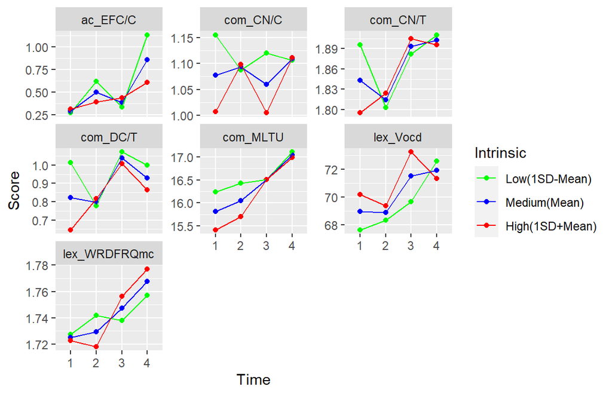

## 3.3 To what extent is that association moderated by the level of task identified motivation?

The association between task repetition and CAL measures moderated by identified motivation

iden

time

cal

Mean

SE

Lower

Upper

t

p-value

Sig.

1.700

1

ac_EFC/C

0.284

0.126

0.034

0.533

2.258

0.026

2.800

1

ac_EFC/C

0.295

0.081

0.134

0.456

3.630

0.000

***

4.000

1

ac_EFC/C

0.307

0.110

0.089

0.526

2.788

0.006

1.700

2

ac_EFC/C

0.526

0.097

0.333

0.719

5.406

0.000

***

2.800

2

ac_EFC/C

0.482

0.062

0.360

0.605

7.814

0.000

***

4.000

2

ac_EFC/C

0.434

0.067

0.302

0.566

6.513

0.000

***

1.700

3

ac_EFC/C

0.343

0.064

0.216

0.470

5.344

0.000

***

2.800

3

ac_EFC/C

0.379

0.054

0.272

0.486

7.016

0.000

***

4.000

3

ac_EFC/C

0.418

0.084

0.251

0.585

4.968

0.000

***

1.700

4

ac_EFC/C

1.130

0.058

1.015

1.246

19.403

0.000

***

2.800

4

ac_EFC/C

0.901

0.048

0.805

0.997

18.607

0.000

***

4.000

4

ac_EFC/C

0.651

0.074

0.504

0.798

8.791

0.000

***

1.700

1

com_CN/C

1.135

0.048

1.040

1.231

23.526

0.000

***

2.800

1

com_CN/C

1.072

0.031

1.010

1.134

34.385

0.000

***

4.000

1

com_CN/C

1.003

0.042

0.919

1.087

23.698

0.000

***

1.700

2

com_CN/C

1.085

0.037

1.012

1.158

29.579

0.000

***

2.800

2

com_CN/C

1.092

0.023

1.046

1.138

47.041

0.000

***

4.000

2

com_CN/C

1.099

0.025

1.049

1.149

43.830

0.000

***

1.700

3

com_CN/C

1.119

0.024

1.071

1.167

46.622

0.000

***

2.800

3

com_CN/C

1.071

0.020

1.031

1.111

53.102

0.000

***

4.000

3

com_CN/C

1.018

0.031

0.956

1.081

32.355

0.000

***

1.700

4

com_CN/C

1.107

0.022

1.065

1.150

51.403

0.000

***

2.800

4

com_CN/C

1.108

0.018

1.073

1.144

61.930

0.000

***

4.000

4

com_CN/C

1.109

0.027

1.054

1.163

40.432

0.000

***

1.700

1

com_CN/T

1.898

0.024

1.850

1.946

78.760

0.000

***

2.800

1

com_CN/T

1.842

0.016

1.811

1.873

118.275

0.000

***

4.000

1

com_CN/T

1.780

0.021

1.738

1.822

84.203

0.000

***

1.700

2

com_CN/T

1.803

0.018

1.766

1.839

98.396

0.000

***

2.800

2

com_CN/T

1.813

0.012

1.790

1.836

156.451

0.000

***

4.000

2

com_CN/T

1.825

0.013

1.800

1.850

145.739

0.000

***

1.700

3

com_CN/T

1.883

0.012

1.859

1.906

157.084

0.000

***

2.800

3

com_CN/T

1.891

0.010

1.871

1.911

187.822

0.000

***

4.000

3

com_CN/T

1.901

0.016

1.869

1.932

120.948

0.000

***

1.700

4

com_CN/T

1.909

0.011

1.888

1.930

177.452

0.000

***

2.800

4

com_CN/T

1.904

0.009

1.886

1.922

213.096

0.000

***

4.000

4

com_CN/T

1.898

0.014

1.871

1.926

138.629

0.000

***

1.700

1

com_DC/T

0.940

0.139

0.665

1.215

6.789

0.000

***

2.800

1

com_DC/T

0.804

0.089

0.627

0.982

8.988

0.000

***

4.000

1

com_DC/T

0.656

0.122

0.415

0.897

5.399

0.000

***

1.700

2

com_DC/T

0.757

0.105

0.548

0.966

7.191

0.000

***

2.800

2

com_DC/T

0.790

0.067

0.658

0.922

11.863

0.000

***

4.000

2

com_DC/T

0.826

0.072

0.683

0.969

11.481

0.000

***

1.700

3

com_DC/T

1.059

0.069

0.923

1.196

15.381

0.000

***

2.800

3

com_DC/T

1.048

0.058

0.933

1.163

18.106

0.000

***

4.000

3

com_DC/T

1.035

0.090

0.856

1.214

11.461

0.000

***

1.700

4

com_DC/T

1.007

0.062

0.884

1.129

16.282

0.000

***

2.800

4

com_DC/T

0.937

0.051

0.835

1.039

18.251

0.000

***

4.000

4

com_DC/T

0.861

0.079

0.705

1.018

10.944

0.000

***

1.700

1

com_MLTU

16.376

0.292

15.796

16.956

56.022

0.000

***

2.800

1

com_MLTU

15.815

0.189

15.440

16.190

83.739

0.000

***

4.000

1

com_MLTU

15.204

0.256

14.695

15.713

59.292

0.000

***

1.700

2

com_MLTU

16.311

0.222

15.870

16.752

73.403

0.000

***

2.800

2

com_MLTU

16.041

0.141

15.762

16.320

114.109

0.000

***

4.000

2

com_MLTU

15.746

0.152

15.445

16.047

103.681

0.000

***

1.700

3

com_MLTU

16.498

0.145

16.210

16.787

113.491

0.000

***

2.800

3

com_MLTU

16.511

0.122

16.269

16.753

135.194

0.000

***

4.000

3

com_MLTU

16.525

0.191

16.147

16.903

86.706

0.000

***

1.700

4

com_MLTU

17.085

0.130

16.826

17.343

130.932

0.000

***

2.800

4

com_MLTU

17.062

0.108

16.847

17.277

157.443

0.000

***

4.000

4

com_MLTU

17.038

0.166

16.708

17.368

102.576

0.000

***

1.700

1

lex_Vocd

67.757

1.669

64.446

71.069

40.595

0.000

***

2.800

1

lex_Vocd

69.035

1.078

66.895

71.175

64.014

0.000

***

4.000

1

lex_Vocd

70.429

1.464

67.524

73.334

48.100

0.000

***

1.700

2

lex_Vocd

68.898

1.269

66.380

71.415

54.300

0.000

***

2.800

2

lex_Vocd

69.029

0.803

67.436

70.622

85.997

0.000

***

4.000

2

lex_Vocd

69.173

0.867

67.452

70.893

79.766

0.000

***

1.700

3

lex_Vocd

69.714

0.830

68.067

71.362

83.985

0.000

***

2.800

3

lex_Vocd

71.181

0.697

69.797

72.565

102.070

0.000

***

4.000

3

lex_Vocd

72.781

1.088

70.621

74.940

66.877

0.000

***

1.700

4

lex_Vocd

72.535

0.745

71.057

74.014

97.352

0.000

***

2.800

4

lex_Vocd

72.054

0.619

70.826

73.282

116.438

0.000

***

4.000

4

lex_Vocd

71.529

0.948

69.647

73.411

75.415

0.000

***

1.700

1

lex_WRDFRQmc

1.729

0.024

1.682

1.775

73.510

0.000

***

2.800

1

lex_WRDFRQmc

1.725

0.015

1.695

1.755

113.513

0.000

***

4.000

1

lex_WRDFRQmc

1.721

0.021

1.680

1.762

83.412

0.000

***

1.700

2

lex_WRDFRQmc

1.736

0.018

1.701

1.772

96.741

0.000

***

2.800

2

lex_WRDFRQmc

1.729

0.011

1.706

1.751

152.221

0.000

***

4.000

2

lex_WRDFRQmc

1.720

0.012

1.696

1.745

140.219

0.000

***

1.700

3

lex_WRDFRQmc

1.738

0.012

1.714

1.761

147.778

0.000

***

2.800

3

lex_WRDFRQmc

1.746

0.010

1.726

1.765

176.707

0.000

***

4.000

3

lex_WRDFRQmc

1.755

0.015

1.724

1.785

113.821

0.000

***

1.700

4

lex_WRDFRQmc

1.756

0.011

1.735

1.777

165.984

0.000

***

2.800

4

lex_WRDFRQmc

1.766

0.009

1.749

1.784

201.030

0.000

***

4.000

4

lex_WRDFRQmc

1.778

0.013

1.751

1.805

132.028

0.000

***

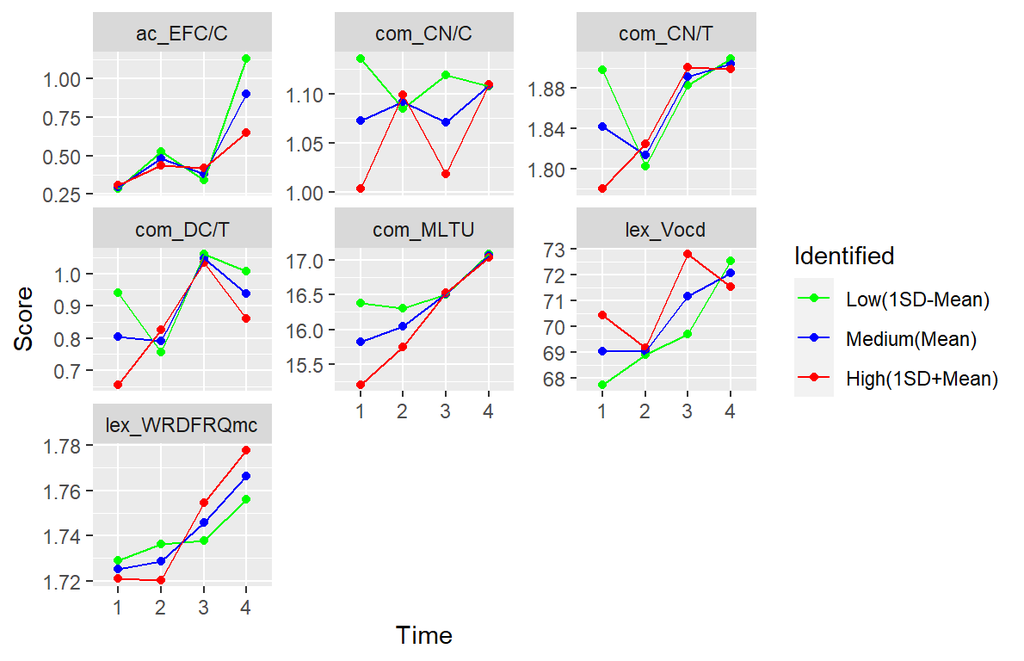

## 3.4 To what extent is that association moderated by the level of task amotivation?

The association between task repetition and CAL measures moderated by amotivation

| amot | time | cal | Mean | SE | Lower | Upper | t | p-value | Sig. |
| --- | --- | --- | --- | --- | --- | --- | --- | --- | --- |
| 2.100 | 1 | ac_EFC/C | 0.334 | 0.099 | 0.136 | 0.531 | 3.354 | 0.001 | ** |
| 3.200 | 1 | ac_EFC/C | 0.284 | 0.082 | 0.121 | 0.447 | 3.448 | 0.001 | *** |
| 4.300 | 1 | ac_EFC/C | 0.234 | 0.130 | -0.023 | 0.492 | 1.805 | 0.074 | . |
| 2.100 | 2 | ac_EFC/C | 0.409 | 0.074 | 0.262 | 0.556 | 5.524 | 0.000 | *** |
| 3.200 | 2 | ac_EFC/C | 0.471 | 0.057 | 0.358 | 0.585 | 8.267 | 0.000 | *** |
| 4.300 | 2 | ac_EFC/C | 0.534 | 0.086 | 0.364 | 0.703 | 6.243 | 0.000 | *** |
| 2.100 | 3 | ac_EFC/C | 0.440 | 0.088 | 0.265 | 0.614 | 4.998 | 0.000 | *** |
| 3.200 | 3 | ac_EFC/C | 0.384 | 0.054 | 0.276 | 0.491 | 7.093 | 0.000 | *** |
| 4.300 | 3 | ac_EFC/C | 0.328 | 0.067 | 0.194 | 0.462 | 4.864 | 0.000 | *** |
| 2.100 | 4 | ac_EFC/C | 0.599 | 0.078 | 0.445 | 0.753 | 7.717 | 0.000 | *** |
| 3.200 | 4 | ac_EFC/C | 0.880 | 0.049 | 0.784 | 0.977 | 18.036 | 0.000 | *** |
| 4.300 | 4 | ac_EFC/C | 1.162 | 0.060 | 1.043 | 1.280 | 19.450 | 0.000 | *** |
| 2.100 | 1 | com_CN/C | 1.036 | 0.038 | 0.960 | 1.113 | 26.978 | 0.000 | *** |
| 3.200 | 1 | com_CN/C | 1.070 | 0.032 | 1.007 | 1.133 | 33.679 | 0.000 | *** |
| 4.300 | 1 | com_CN/C | 1.104 | 0.050 | 1.005 | 1.204 | 22.018 | 0.000 | *** |
| 2.100 | 2 | com_CN/C | 1.109 | 0.028 | 1.054 | 1.165 | 39.599 | 0.000 | *** |
| 3.200 | 2 | com_CN/C | 1.092 | 0.022 | 1.050 | 1.135 | 50.709 | 0.000 | *** |
| 4.300 | 2 | com_CN/C | 1.076 | 0.032 | 1.011 | 1.140 | 33.232 | 0.000 | *** |
| 2.100 | 3 | com_CN/C | 1.001 | 0.033 | 0.935 | 1.066 | 30.276 | 0.000 | *** |
| 3.200 | 3 | com_CN/C | 1.066 | 0.020 | 1.026 | 1.107 | 52.557 | 0.000 | *** |
| 4.300 | 3 | com_CN/C | 1.132 | 0.025 | 1.082 | 1.182 | 44.736 | 0.000 | *** |
| 2.100 | 4 | com_CN/C | 1.115 | 0.029 | 1.058 | 1.172 | 38.694 | 0.000 | *** |
| 3.200 | 4 | com_CN/C | 1.109 | 0.018 | 1.074 | 1.145 | 61.341 | 0.000 | *** |
| 4.300 | 4 | com_CN/C | 1.104 | 0.022 | 1.060 | 1.148 | 49.811 | 0.000 | *** |
| 2.100 | 1 | com_CN/T | 1.784 | 0.019 | 1.746 | 1.821 | 93.659 | 0.000 | *** |
| 3.200 | 1 | com_CN/T | 1.849 | 0.016 | 1.818 | 1.881 | 117.395 | 0.000 | *** |
| 4.300 | 1 | com_CN/T | 1.915 | 0.025 | 1.866 | 1.964 | 77.035 | 0.000 | *** |
| 2.100 | 2 | com_CN/T | 1.825 | 0.014 | 1.798 | 1.853 | 131.468 | 0.000 | *** |
| 3.200 | 2 | com_CN/T | 1.817 | 0.011 | 1.796 | 1.838 | 170.134 | 0.000 | *** |
| 4.300 | 2 | com_CN/T | 1.808 | 0.016 | 1.776 | 1.840 | 112.702 | 0.000 | *** |

[output cut: 54 more lines]

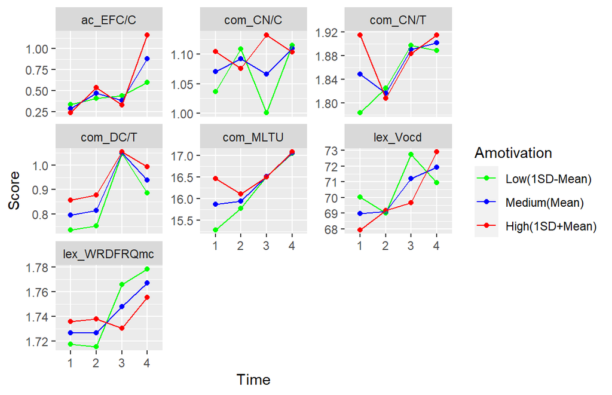

## 3.5 To what extent is that association moderated by the level of task intention?

The association between task repetition and CAL measures moderated by task intention

| inten | time | cal | Mean | SE | Lower | Upper | t | p-value | Sig. |
| --- | --- | --- | --- | --- | --- | --- | --- | --- | --- |
| 1.700 | 1 | ac_EFC/C | 0.261 | 0.133 | -0.003 | 0.525 | 1.964 | 0.052 | . |
| 2.900 | 1 | ac_EFC/C | 0.289 | 0.084 | 0.123 | 0.456 | 3.451 | 0.001 | *** |
| 4.100 | 1 | ac_EFC/C | 0.318 | 0.101 | 0.117 | 0.519 | 3.138 | 0.002 | ** |
| 1.700 | 2 | ac_EFC/C | 0.599 | 0.104 | 0.393 | 0.805 | 5.778 | 0.000 | *** |
| 2.900 | 2 | ac_EFC/C | 0.501 | 0.062 | 0.378 | 0.624 | 8.092 | 0.000 | *** |
| 4.100 | 2 | ac_EFC/C | 0.403 | 0.068 | 0.268 | 0.538 | 5.927 | 0.000 | *** |
| 1.700 | 3 | ac_EFC/C | 0.332 | 0.066 | 0.201 | 0.463 | 5.028 | 0.000 | *** |
| 2.900 | 3 | ac_EFC/C | 0.386 | 0.056 | 0.276 | 0.497 | 6.946 | 0.000 | *** |
| 4.100 | 3 | ac_EFC/C | 0.440 | 0.091 | 0.260 | 0.621 | 4.842 | 0.000 | *** |
| 1.700 | 4 | ac_EFC/C | 1.109 | 0.060 | 0.990 | 1.227 | 18.605 | 0.000 | *** |
| 2.900 | 4 | ac_EFC/C | 0.881 | 0.051 | 0.781 | 0.982 | 17.420 | 0.000 | *** |
| 4.100 | 4 | ac_EFC/C | 0.654 | 0.083 | 0.490 | 0.818 | 7.915 | 0.000 | *** |
| 1.700 | 1 | com_CN/C | 1.142 | 0.051 | 1.041 | 1.243 | 22.543 | 0.000 | *** |
| 2.900 | 1 | com_CN/C | 1.078 | 0.032 | 1.015 | 1.142 | 33.759 | 0.000 | *** |
| 4.100 | 1 | com_CN/C | 1.015 | 0.039 | 0.938 | 1.091 | 26.277 | 0.000 | *** |
| 1.700 | 2 | com_CN/C | 1.077 | 0.039 | 1.000 | 1.154 | 27.766 | 0.000 | *** |
| 2.900 | 2 | com_CN/C | 1.090 | 0.023 | 1.044 | 1.136 | 47.112 | 0.000 | *** |
| 4.100 | 2 | com_CN/C | 1.102 | 0.025 | 1.052 | 1.153 | 43.361 | 0.000 | *** |
| 1.700 | 3 | com_CN/C | 1.120 | 0.025 | 1.072 | 1.169 | 45.671 | 0.000 | *** |
| 2.900 | 3 | com_CN/C | 1.066 | 0.021 | 1.025 | 1.107 | 51.691 | 0.000 | *** |
| 4.100 | 3 | com_CN/C | 1.012 | 0.034 | 0.945 | 1.080 | 29.952 | 0.000 | *** |
| 1.700 | 4 | com_CN/C | 1.105 | 0.022 | 1.062 | 1.149 | 50.464 | 0.000 | *** |
| 2.900 | 4 | com_CN/C | 1.109 | 0.019 | 1.072 | 1.146 | 59.708 | 0.000 | *** |
| 4.100 | 4 | com_CN/C | 1.113 | 0.030 | 1.053 | 1.173 | 36.625 | 0.000 | *** |
| 1.700 | 1 | com_CN/T | 1.899 | 0.025 | 1.849 | 1.949 | 75.090 | 0.000 | *** |
| 2.900 | 1 | com_CN/T | 1.846 | 0.016 | 1.814 | 1.878 | 115.770 | 0.000 | *** |
| 4.100 | 1 | com_CN/T | 1.793 | 0.019 | 1.755 | 1.831 | 93.020 | 0.000 | *** |
| 1.700 | 2 | com_CN/T | 1.806 | 0.019 | 1.767 | 1.844 | 93.230 | 0.000 | *** |
| 2.900 | 2 | com_CN/T | 1.815 | 0.012 | 1.792 | 1.837 | 157.126 | 0.000 | *** |
| 4.100 | 2 | com_CN/T | 1.823 | 0.013 | 1.798 | 1.848 | 143.658 | 0.000 | *** |

[output cut: 54 more lines]

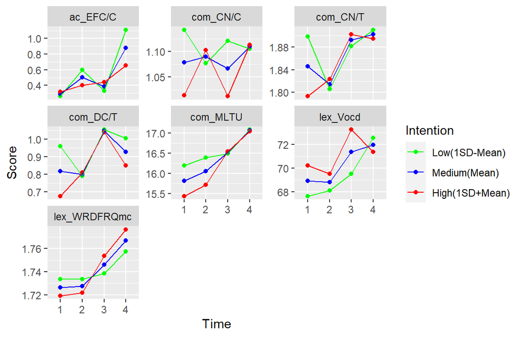

# 4 RQ2c

## 4.1 To what extent is that association moderated by the degree of time on task?

The association between task repetition and CAL measures moderated by time on task

time_on_task

time

cal

Mean

SE

Lower

Upper

t

p-value

Sig.

28.000

1

ac_EFC/C

0.279

0.124

0.032

0.526

2.244

0.027

32.600

1

ac_EFC/C

0.295

0.083

0.130

0.461

3.542

0.001

***

37.200

1

ac_EFC/C

0.312

0.112

0.089

0.535

2.774

0.007

28.000

2

ac_EFC/C

0.572

0.104

0.365

0.778

5.500

0.000

***

32.600

2

ac_EFC/C

0.486

0.061

0.364

0.608

7.917

0.000

***

37.200

2

ac_EFC/C

0.401

0.076

0.250

0.551

5.287

0.000

***

28.000

3

ac_EFC/C

0.370

0.064

0.243

0.497

5.778

0.000

***

32.600

3

ac_EFC/C

0.370

0.056

0.258

0.482

6.555

0.000

***

37.200

3

ac_EFC/C

0.369

0.082

0.207

0.532

4.506

0.000

***

28.000

4

ac_EFC/C

0.952

0.068

0.817

1.088

13.913

0.000

***

32.600

4

ac_EFC/C

0.952

0.050

0.852

1.051

18.987

0.000

***

37.200

4

ac_EFC/C

0.951

0.078

0.797

1.106

12.228

0.000

***

28.000

1

com_CN/C

1.108

0.047

1.015

1.201

23.698

0.000

***

32.600

1

com_CN/C

1.066

0.031

1.004

1.127

34.157

0.000

***

37.200

1

com_CN/C

1.023

0.042

0.939

1.107

24.237

0.000

***

28.000

2

com_CN/C

1.088

0.038

1.012

1.163

28.547

0.000

***

32.600

2

com_CN/C

1.093

0.022

1.049

1.137

49.011

0.000

***

37.200

2

com_CN/C

1.099

0.028

1.044

1.154

39.702

0.000

***

28.000

3

com_CN/C

1.113

0.023

1.067

1.159

48.121

0.000

***

32.600

3

com_CN/C

1.070

0.020

1.030

1.110

52.741

0.000

***

37.200

3

com_CN/C

1.027

0.030

0.968

1.086

34.531

0.000

***

28.000

4

com_CN/C

1.092

0.024

1.043

1.140

44.681

0.000

***

32.600

4

com_CN/C

1.110

0.018

1.075

1.145

62.591

0.000

***

37.200

4

com_CN/C

1.128

0.028

1.073

1.183

40.528

0.000

***

28.000

1

com_CN/T

1.897

0.023

1.851

1.942

82.187

0.000

***

32.600

1

com_CN/T

1.838

0.015

1.807

1.868

119.367

0.000

***

37.200

1

com_CN/T

1.779

0.021

1.738

1.820

85.399

0.000

***

28.000

2

com_CN/T

1.808

0.019

1.771

1.846

96.164

0.000

***

32.600

2

com_CN/T

1.816

0.011

1.794

1.838

164.953

0.000

***

37.200

2

com_CN/T

1.823

0.014

1.796

1.851

133.503

0.000

***

28.000

3

com_CN/T

1.879

0.011

1.856

1.901

164.574

0.000

***

32.600

3

com_CN/T

1.893

0.010

1.874

1.913

189.070

0.000

***

37.200

3

com_CN/T

1.908

0.015

1.879

1.937

129.957

0.000

***

28.000

4

com_CN/T

1.916

0.012

1.893

1.940

158.887

0.000

***

32.600

4

com_CN/T

1.904

0.009

1.886

1.921

217.465

0.000

***

37.200

4

com_CN/T

1.891

0.014

1.863

1.918

137.608

0.000

***

28.000

1

com_DC/T

0.913

0.133

0.648

1.177

6.854

0.000

***

32.600

1

com_DC/T

0.793

0.089

0.617

0.969

8.923

0.000

***

37.200

1

com_DC/T

0.673

0.120

0.434

0.912

5.598

0.000

***

28.000

2

com_DC/T

0.796

0.109

0.581

1.011

7.337

0.000

***

32.600

2

com_DC/T

0.803

0.064

0.677

0.929

12.641

0.000

***

37.200

2

com_DC/T

0.810

0.079

0.653

0.966

10.275

0.000

***

28.000

3

com_DC/T

1.031

0.066

0.901

1.162

15.658

0.000

***

32.600

3

com_DC/T

1.059

0.058

0.944

1.173

18.319

0.000

***

37.200

3

com_DC/T

1.086

0.085

0.918

1.254

12.815

0.000

***

28.000

4

com_DC/T

1.079

0.070

0.941

1.217

15.500

0.000

***

32.600

4

com_DC/T

0.935

0.051

0.835

1.036

18.518

0.000

***

37.200

4

com_DC/T

0.792

0.079

0.635

0.949

9.988

0.000

***

28.000

1

com_MLTU

16.094

0.284

15.531

16.658

56.645

0.000

***

32.600

1

com_MLTU

15.753

0.190

15.376

16.129

83.096

0.000

***

37.200

1

com_MLTU

15.411

0.257

14.902

15.920

60.079

0.000

***

28.000

2

com_MLTU

16.375

0.232

15.915

16.834

70.726

0.000

***

32.600

2

com_MLTU

16.019

0.136

15.750

16.288

118.186

0.000

***

37.200

2

com_MLTU

15.664

0.168

15.330

15.997

93.138

0.000

***

28.000

3

com_MLTU

16.495

0.141

16.216

16.774

117.360

0.000

***

32.600

3

com_MLTU

16.513

0.123

16.269

16.758

133.920

0.000

***

37.200

3

com_MLTU

16.531

0.181

16.172

16.890

91.436

0.000

***

28.000

4

com_MLTU

17.075

0.149

16.780

17.370

114.972

0.000

***

32.600

4

com_MLTU

17.066

0.108

16.852

17.280

158.345

0.000

***

37.200

4

com_MLTU

17.057

0.169

16.722

17.393

100.830

0.000

***

28.000

1

lex_Vocd

68.703

1.615

65.498

71.907

42.540

0.000

***

32.600

1

lex_Vocd

69.206

1.078

67.067

71.344

64.225

0.000

***

37.200

1

lex_Vocd

69.708

1.458

66.815

72.601

47.810

0.000

***

28.000

2

lex_Vocd

69.531

1.316

66.920

72.142

52.835

0.000

***

32.600

2

lex_Vocd

69.185

0.770

67.656

70.714

89.799

0.000

***

37.200

2

lex_Vocd

68.839

0.956

66.943

70.736

72.012

0.000

***

28.000

3

lex_Vocd

69.907

0.799

68.322

71.492

87.502

0.000

***

32.600

3

lex_Vocd

71.194

0.701

69.804

72.585

101.577

0.000

***

37.200

3

lex_Vocd

72.482

1.028

70.443

74.521

70.531

0.000

***

28.000

4

lex_Vocd

73.043

0.844

71.368

74.718

86.526

0.000

***

32.600

4

lex_Vocd

72.040

0.613

70.825

73.256

117.593

0.000

***

37.200

4

lex_Vocd

71.038

0.962

69.130

72.946

73.876

0.000

***

28.000

1

lex_WRDFRQmc

1.728

0.023

1.683

1.774

76.038

0.000

***

32.600

1

lex_WRDFRQmc

1.725

0.015

1.695

1.755

113.712

0.000

***

37.200

1

lex_WRDFRQmc

1.721

0.021

1.680

1.762

83.861

0.000

***

28.000

2

lex_WRDFRQmc

1.735

0.019

1.698

1.772

93.518

0.000

***

32.600

2

lex_WRDFRQmc

1.727

0.011

1.706

1.749

159.019

0.000

***

37.200

2

lex_WRDFRQmc

1.720

0.013

1.693

1.746

127.601

0.000

***

28.000

3

lex_WRDFRQmc

1.735

0.011

1.712

1.757

153.940

0.000

***

32.600

3

lex_WRDFRQmc

1.748

0.010

1.728

1.767

176.755

0.000

***

37.200

3

lex_WRDFRQmc

1.760

0.014

1.732

1.789

121.442

0.000

***

28.000

4

lex_WRDFRQmc

1.751

0.012

1.728

1.775

146.940

0.000

***

32.600

4

lex_WRDFRQmc

1.766

0.009

1.749

1.783

204.158

0.000

***

37.200

4

lex_WRDFRQmc

1.781

0.014

1.754

1.807

131.166

0.000

***

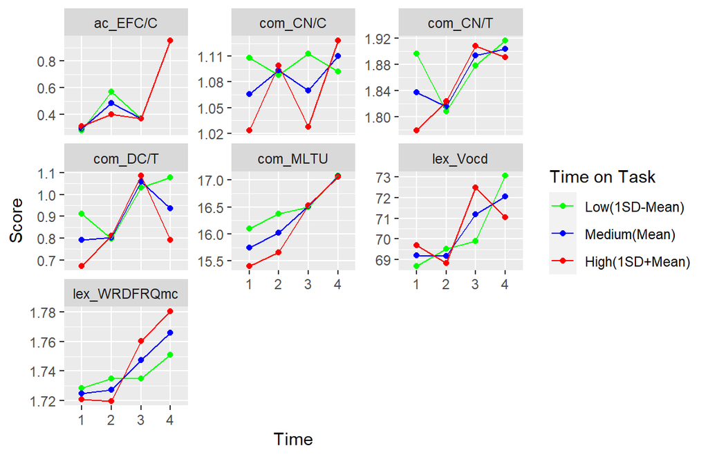

## 4.2 To what extent is that association moderated by the length of writing?

The association between task repetition and CAL measures moderated by writing length

length_writing

time

cal

Mean

SE

Lower

Upper

t

p-value

Sig.

337.300

1

ac_EFC/C

0.285

0.106

0.074

0.496

2.684

0.009

385.100

1

ac_EFC/C

0.300

0.085

0.132

0.469

3.537

0.001

***

433.000

1

ac_EFC/C

0.316

0.134

0.051

0.581

2.364

0.020

337.300

2

ac_EFC/C

0.473

0.070

0.335

0.612

6.786

0.000

***

385.100

2

ac_EFC/C

0.454

0.065

0.325

0.583

6.979

0.000

***

433.000

2

ac_EFC/C

0.435

0.114

0.208

0.662

3.799

0.000

***

337.300

3

ac_EFC/C

0.439

0.094

0.253

0.625

4.685

0.000

***

385.100

3

ac_EFC/C

0.394

0.061

0.273

0.515

6.484

0.000

***

433.000

3

ac_EFC/C

0.349

0.059

0.232

0.467

5.900

0.000

***

337.300

4

ac_EFC/C

1.151

0.081

0.990

1.312

14.156

0.000

***

385.100

4

ac_EFC/C

0.973

0.050

0.874

1.072

19.503

0.000

***

433.000

4

ac_EFC/C

0.796

0.071

0.655

0.936

11.233

0.000

***

337.300

1

com_CN/C

1.035

0.040

0.955

1.115

25.676

0.000

***

385.100

1

com_CN/C

1.069

0.032

1.005

1.133

33.263

0.000

***

433.000

1

com_CN/C

1.103

0.051

1.002

1.204

21.680

0.000

***

337.300

2

com_CN/C

1.083

0.026

1.032

1.134

42.342

0.000

***

385.100

2

com_CN/C

1.104

0.024

1.057

1.151

46.354

0.000

***

433.000

2

com_CN/C

1.125

0.042

1.041

1.209

26.572

0.000

***

337.300

3

com_CN/C

1.014

0.034

0.946

1.082

29.577

0.000

***

385.100

3

com_CN/C

1.059

0.022

1.015

1.102

48.039

0.000

***

433.000

3

com_CN/C

1.103

0.021

1.061

1.146

51.453

0.000

***

337.300

4

com_CN/C

1.108

0.029

1.050

1.166

37.897

0.000

***

385.100

4

com_CN/C

1.108

0.018

1.073

1.143

62.607

0.000

***

433.000

4

com_CN/C

1.108

0.025

1.057

1.158

43.589

0.000

***

337.300

1

com_CN/T

1.841

0.020

1.801

1.881

91.385

0.000

***

385.100

1

com_CN/T

1.829

0.016

1.797

1.861

113.887

0.000

***

433.000

1

com_CN/T

1.817

0.025

1.767

1.868

71.473

0.000

***

337.300

2

com_CN/T

1.802

0.013

1.777

1.828

140.973

0.000

***

385.100

2

com_CN/T

1.830

0.012

1.807

1.854

153.756

0.000

***

433.000

2

com_CN/T

1.858

0.021

1.816

1.900

87.820

0.000

***

337.300

3

com_CN/T

1.888

0.017

1.854

1.922

110.156

0.000

***

385.100

3

com_CN/T

1.889

0.011

1.867

1.910

171.456

0.000

***

433.000

3

com_CN/T

1.890

0.011

1.868

1.911

176.280

0.000

***

337.300

4

com_CN/T

1.911

0.015

1.882

1.940

130.698

0.000

***

385.100

4

com_CN/T

1.906

0.009

1.888

1.923

215.429

0.000

***

433.000

4

com_CN/T

1.901

0.013

1.876

1.926

149.649

0.000

***

337.300

1

com_DC/T

0.757

0.114

0.530

0.984

6.616

0.000

***

385.100

1

com_DC/T

0.788

0.091

0.607

0.969

8.639

0.000

***

433.000

1

com_DC/T

0.819

0.144

0.532

1.105

5.672

0.000

***

337.300

2

com_DC/T

0.900

0.073

0.756

1.044

12.397

0.000

***

385.100

2

com_DC/T

0.732

0.068

0.598

0.867

10.839

0.000

***

433.000

2

com_DC/T

0.565

0.120

0.326

0.803

4.702

0.000

***

337.300

3

com_DC/T

1.067

0.097

0.874

1.260

10.967

0.000

***

385.100

3

com_DC/T

1.056

0.063

0.932

1.180

16.892

0.000

***

433.000

3

com_DC/T

1.046

0.061

0.925

1.167

17.185

0.000

***

337.300

4

com_DC/T

0.798

0.083

0.633

0.963

9.617

0.000

***

385.100

4

com_DC/T

0.936

0.050

0.836

1.036

18.635

0.000

***

433.000

4

com_DC/T

1.074

0.072

0.931

1.217

14.893

0.000

***

337.300

1

com_MLTU

15.627

0.247

15.136

16.118

63.190

0.000

***

385.100

1

com_MLTU

15.745

0.197

15.354

16.136

79.865

0.000

***

433.000

1

com_MLTU

15.863

0.312

15.244

16.482

50.832

0.000

***

337.300

2

com_MLTU

15.917

0.157

15.606

16.229

101.447

0.000

***

385.100

2

com_MLTU

15.921

0.146

15.631

16.211

108.980

0.000

***

433.000

2

com_MLTU

15.925

0.260

15.410

16.440

61.321

0.000

***

337.300

3

com_MLTU

16.510

0.210

16.093

16.927

78.501

0.000

***

385.100

3

com_MLTU

16.509

0.135

16.240

16.777

122.111

0.000

***

433.000

3

com_MLTU

16.507

0.132

16.246

16.768

125.470

0.000

***

337.300

4

com_MLTU

16.949

0.179

16.592

17.305

94.464

0.000

***

385.100

4

com_MLTU

17.054

0.109

16.839

17.270

157.076

0.000

***

433.000

4

com_MLTU

17.161

0.156

16.851

17.470

110.074

0.000

***

337.300

1

lex_Vocd

69.618

1.397

66.847

72.389

49.851

0.000

***

385.100

1

lex_Vocd

69.152

1.113

66.942

71.361

62.111

0.000

***

433.000

1

lex_Vocd

68.684

1.762

65.188

72.181

38.978

0.000

***

337.300

2

lex_Vocd

68.715

0.889

66.950

70.479

77.274

0.000

***

385.100

2

lex_Vocd

69.374

0.828

67.731

71.017

83.783

0.000

***

433.000

2

lex_Vocd

70.034

1.472

67.114

72.954

47.591

0.000

***

337.300

3

lex_Vocd

71.729

1.193

69.362

74.095

60.130

0.000

***

385.100

3

lex_Vocd

71.136

0.767

69.614

72.658

92.750

0.000

***

433.000

3

lex_Vocd

70.543

0.746

69.062

72.024

94.512

0.000

***

337.300

4

lex_Vocd

71.931

1.020

69.908

73.954

70.543

0.000

***

385.100

4

lex_Vocd

72.136

0.617

70.911

73.360

116.866

0.000

***

433.000

4

lex_Vocd

72.341

0.886

70.582

74.099

81.642

0.000

***

337.300

1

lex_WRDFRQmc

1.731

0.020

1.692

1.769

88.142

0.000

***

385.100

1

lex_WRDFRQmc

1.723

0.016

1.692

1.754

110.056

0.000

***

433.000

1

lex_WRDFRQmc

1.715

0.025

1.666

1.764

69.214

0.000

***

337.300

2

lex_WRDFRQmc

1.734

0.012

1.709

1.759

138.776

0.000

***

385.100

2

lex_WRDFRQmc

1.719

0.012

1.696

1.742

147.741

0.000

***

433.000

2

lex_WRDFRQmc

1.704

0.021

1.663

1.745

82.394

0.000

***

337.300

3

lex_WRDFRQmc

1.757

0.017

1.724

1.790

104.839

0.000

***

385.100

3

lex_WRDFRQmc

1.748

0.011

1.727

1.770

162.286

0.000

***

433.000

3

lex_WRDFRQmc

1.740

0.010

1.719

1.761

165.954

0.000

***

337.300

4

lex_WRDFRQmc

1.764

0.014

1.736

1.792

123.199

0.000

***

385.100

4

lex_WRDFRQmc

1.764

0.009

1.747

1.781

203.547

0.000

***

433.000

4

lex_WRDFRQmc

1.764

0.012

1.739

1.789

141.791

0.000

***

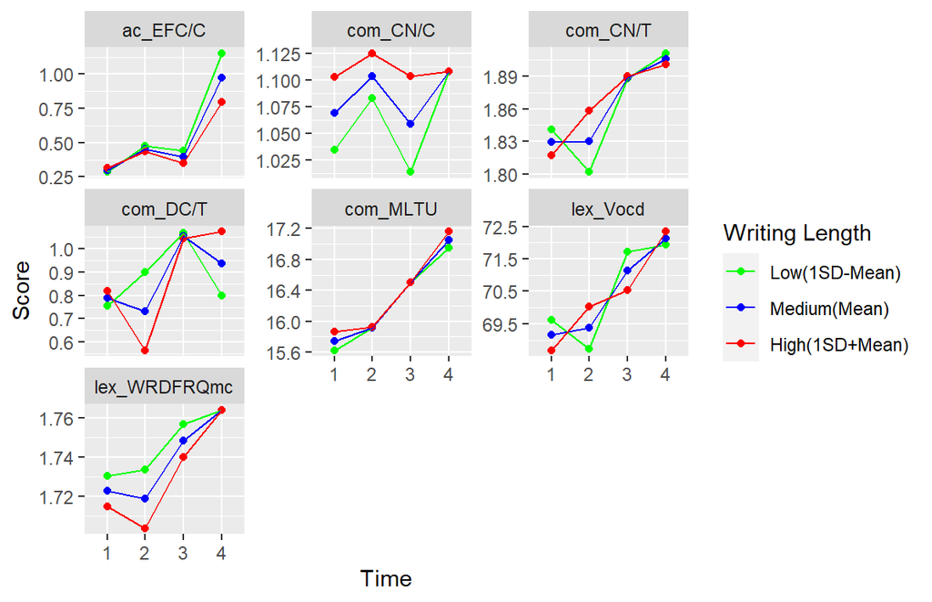